# **Enterprise Sales**

**Author:** Ehijele David  
**Notebook:** Enterprise Sales Pipeline  
**Dataset**: Enterprise Sales Pipeline (2022–2026) **Date:** 25/03/2026

This is an Enterprise Sales record of how a sales team operates. It tracks every deal, every customer interaction, every sales rep, and every client company from 2022 to early 2026.

The goal of this Analysis is to come up with thtis top 5 findings:

1. What is the win rate by sales stage, and where do deals die most often? Rationale: If I can see where the biggest drop-off happens... say, 60% of deals die at Proposal... that tells leadership exactly where to intervene with training
2. Which sales reps are punching above their weight, and which are underperforming relative to their seniority? Rationale: A junior sales rep outperforming a senior rep deserves promoting, while a senior sales rep underperforming a junior is a red flag
3. Does higher activity volume actually lead to better deal outcomes, or is it just noise? Rationale: Are deals that got 20 calls more likely to close than those with 5? Or does excessive activity signal a deal that's dragging and unlikely to win?
4. Which industries, company sizes, or regions generate the highest deal value AND the best win rates? Rationale: A company could be winning lots of SMB deals at low value while losing nearly every Enterprise deal
5. How long does it typically take to close a deal? Does this vary by deal size, industry, or sales rep? And how has pipeline performance trended year-over-year from 2022 to 2026? Rationale: Is the team getting better or worse at closing? Is the average deal value rising?

## **SET-UP & CONFIGURATIONS**

```
✓ Phase 0 complete. Libraries loaded, chart style set, output folder ready.
  Output folder: /content/drive/MyDrive/Advanced Data Analytics/Enterprise Sales/sales_pipeline_outputs
```

## **DATA INGESTION & VALIDATION**

- Load every sheet into its own dataframe.
- Run sanity checks before touching the data for analysis.
- If something looks wrong here, fix it before moving on.

```
Loading sheets from Excel workbook...
✓ All sheets loaded.

Sheet                  Rows   Expected   Cols  Columns
────────────────────────────────────────────────────────────────────────────────
FactDeals            11,750      11750    11  ✓
  └ ['DealID', 'CompanyID', 'RepID', 'CreatedDateKey', 'LastActivityDateKey', 'StageName', 'StageOrder', 'Status', 'BaseWinProbability', 'DealValueEUR', 'ProductCategory']
FactActivities      117,500     117500     7  ✓
  └ ['ActivityID', 'DealID', 'RepID', 'ActivityType', 'ActivityDateKey', 'DurationMinutes', 'ProductCategory']
DimCompany            1,000       1000     9  ✓
  └ ['CompanyID', 'Industry', 'CompanySize', 'EmployeeCount', 'AnnualRevenueEUR', 'Country', 'Region', 'Latitude', 'Longitude']
DimSalesRep              55         55     7  ✓
  └ ['RepID', 'RepName', 'Region', 'Role', 'Seniority', 'JoinYear', 'LeaveYear']
DimDate               1,492          —     7  ✓
  └ ['Date', 'DateKey', 'Year', 'Quarter', 'Month', 'MonthName', 'Week']

── Null check (critical columns only) ──────────────────────────────────
  ✓  df_deals: no nulls in critical columns
  ✓  df_activities: no nulls in critical columns
  ✓  df_company: no nulls in critical columns
  ✓  df_rep: no nulls in critical columns
  ✓  df_date: no nulls in critical columns

── Categorical value check ──────────────────────────────────────────────

  Status values      : ['Lost', 'Open', 'Won']
  StageName values   : ['Closing', 'Contracting', 'Lead In', 'Negotiation', 'Proposal', 'Qualified']
  StageOrder values  : [np.int64(1), np.int64(2), np.int64(3), np.int64(4), np.int64(5)]
  ActivityType values: ['Call', 'Demo', 'Email', 'Meeting', 'Workshop']
  CompanySize values : ['Enterprise', 'Mid-Market', 'SMB']
  Seniority values   : ['Junior', 'Mid', 'Senior']

── Duplicate primary key check ──────────────────────────────────────────
  FactDeals.DealID                   : ✓ unique
  FactActivities.ActivityID          : ✓ unique
  DimCompany.CompanyID               : ✓ unique
  DimSalesRep.RepID                  : ✓ unique
  DimDate.DateKey                    : ✓ unique

── DealValueEUR sanity ──────────────────────────────────────────────────
  Min    : €    2,728.00
  Max    : €1,083,548.00
  Mean   : €   87,038.58
  Median : €   49,627.50
  Zeros  : 0
  Negatives: 0

── Date range check ─────────────────────────────────────────────────────
  DimDate spans: 2022 – 2026
  Deals created key range: 20220701 – 20251227
  Last activity key range: 20220707 – 20260131

════════════════════════════════════════════════════════════
✓ Phase 1 complete — data looks clean. Ready for Phase 2.
════════════════════════════════════════════════════════════
```

## **DATA PREPARATION & JOINS**

The current stage of work converts date keys into actual dates while it determines the duration of deal cycles and creates three main tables which include an enhanced deals table that links to company and representative dimensions and a subset that contains resolved data for win rate calculations and a comprehensive summary of deal activities which will be used for correlation research.

```
  Cycle days — min: 1, max: 688, negatives: 0
  ✓ All stage names match STAGE_ORDER

  df_master shape: (11750, 26)
  Columns: ['DealID', 'CompanyID', 'RepID', 'CreatedDateKey', 'LastActivityDateKey', 'StageName', 'StageOrder', 'Status', 'BaseWinProbability', 'DealValueEUR', 'ProductCategory', 'created_date', 'last_activity_date', 'cycle_days', 'created_year', 'created_quarter', 'Industry', 'CompanySize', 'compan…

  Total deals   : 11,750
  Resolved deals: 4,981  (42.4%)
  Open deals    : 6,769
  Overall win rate (resolved): 60.2%

  df_with_activity shape: (4981, 34)
  Avg activities per deal: 10.0
  Avg minutes per deal   : 400

════════════════════════════════════════════════════════════
✓ Phase 2 complete. Two master tables ready:
  df_master        — all deals enriched with company & rep dims
  df_resolved      — Won/Lost only, with is_won flag
  df_with_activity — df_resolved + per-deal activity counts
════════════════════════════════════════════════════════════
```

## **WIN RATE BY STAGE & DEAL DEATH MAP**

This section analyses where deals are won, lost, and stalled across the pipeline funnel, revealing which stage represents the biggest intervention opportunity for leadership.

```
Stage-level summary:
  StageName  total_deals  won_deals  lost_deals  open_deals  win_rate  lost_value
    Lead In         3125        737         559        1829 56.867284    51165124
  Qualified         2588        670         437        1481 60.523939    40339526
   Proposal         2414        632         392        1390 61.718750    33481894
Negotiation         2021        531         314        1176 62.840237    27787548
    Closing          846        273         151         422 64.386792     7751112
Contracting          756        156         129         471 54.736842    15325480
  Saved → /content/drive/MyDrive/Advanced Data Analytics/Enterprise Sales/sales_pipeline_outputs/D1_win_rate_by_stage.png
```

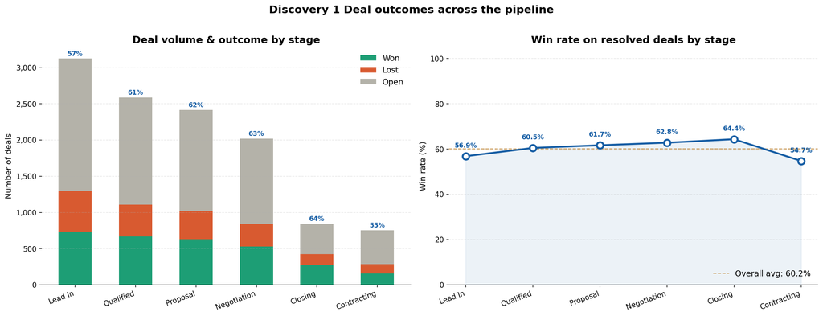

```
  Saved → /content/drive/MyDrive/Advanced Data Analytics/Enterprise Sales/sales_pipeline_outputs/D1_lost_value_by_stage.png
```

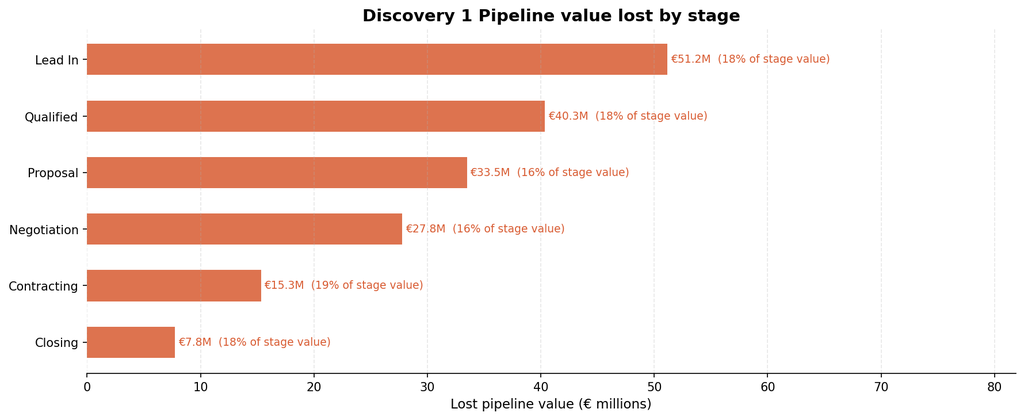

```
════════════════════════════════════════════════════════════
DISCOVERY 1 KEY FINDINGS
════════════════════════════════════════════════════════════

  Highest value loss  : Lead In — €51.2M lost (57% win rate)
  Strongest stage     : Closing — 64% win rate
  Total lost value    : €175.9M across all stages
  Overall win rate    : 60.2% (resolved deals)

  → The stage with the most lost value is the primary training
    and process intervention target for leadership.
════════════════════════════════════════════════════════════
```

The data indicates that the win rate progresses from Lead In at 56.9% to Closing which records 64.4% because deals receive proper qualification throughout their progression. The win rate reaches its lowest point at 54.7% during the Contracting stage which breaks the established win rate pattern. Lead In accounts for the most lost value (€51.2M) simply due to volume, but Contracting represents the most inefficient stage relative to how far those deals have already travelled. Total resolved pipeline value lost across all stages: €175.9M.

The recommendation requires two different interventions because Lead In requires volume-level lead qualification improvements to decrease early drop-off while the team needs to investigate the reasons behind late-stage Contracting failures which probably involve commercial and legal and pricing problems that arise too late in the workflow.

## **Sales Rep performance vs seniority benchmarking**

This section ranks every sales rep against their seniority peers across win rate, deal value, and volume, surfacing who is punching above their weight and who represents a coaching or structural concern for leadership.

```
Seniority tier benchmarks:
Seniority  tier_deals  tier_win_rate  tier_avg_size  tier_reps
   Junior        1252      59.265176   89506.303514         14
      Mid        2089      60.842508   82168.969842         26
   Senior        1640      60.121951   81069.052439         15

Rep performance distribution:
performance
At tier       34
Below tier    12
Above tier     9
  Saved → /content/drive/MyDrive/Advanced Data Analytics/Enterprise Sales/sales_pipeline_outputs/D2_rep_win_rate_by_seniority.png
```

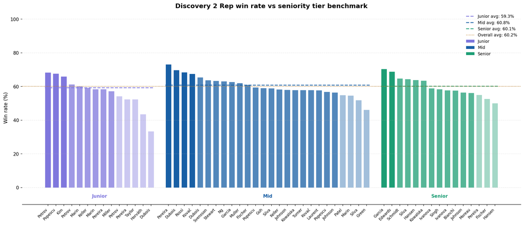

```
  Saved → /content/drive/MyDrive/Advanced Data Analytics/Enterprise Sales/sales_pipeline_outputs/D2_scatter_win_rate_vs_deal_size.png
```

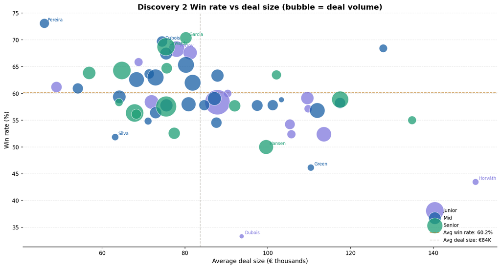

```
════════════════════════════════════════════════════════════
DISCOVERY 2 KEY FINDINGS
════════════════════════════════════════════════════════════

Seniority tier benchmarks:
  Junior  : 59.3% win rate  |  €89,506 avg deal  |  14 reps  |  1,252 resolved deals
  Mid     : 60.8% win rate  |  €82,169 avg deal  |  26 reps  |  2,089 resolved deals
  Senior  : 60.1% win rate  |  €81,069 avg deal  |  15 reps  |  1,640 resolved deals

  --- Junior tier ---
  Top performers (vs tier):
    Hugo Petrov            WR: 68.3%  (+9.0pp vs tier)  Avg deal: €77,980
    Clara Popescu          WR: 67.6%  (+8.3pp vs tier)  Avg deal: €81,263
    Kiran Kim              WR: 65.9%  (+6.6pp vs tier)  Avg deal: €68,807
  Underperformers (vs tier):
    Elena Dubois           WR: 33.3%  (-25.9pp vs tier)  Avg deal: €93,696
    Lukas Horváth          WR: 43.5%  (-15.8pp vs tier)  Avg deal: €150,190
    Inga Pereira           WR: 52.4%  (-6.9pp vs tier)  Avg deal: €105,712

  --- Mid tier ---
  Top performers (vs tier):
    Isabelle Pereira       WR: 73.1%  (+12.2pp vs tier)  Avg deal: €46,063
    Petra Dubois           WR: 69.7%  (+8.9pp vs tier)  Avg deal: €74,476
    Jonas Rossi            WR: 68.4%  (+7.6pp vs tier)  Avg deal: €127,900
  Underperformers (vs tier):
    James Green            WR: 46.2%  (-14.7pp vs tier)  Avg deal: €110,407
    Noemi Silva            WR: 51.9%  (-9.0pp vs tier)  Avg deal: €63,155
    Petra Marin            WR: 54.5%  (-6.3pp vs tier)  Avg deal: €87,605

  --- Senior tier ---
  Top performers (vs tier):
    Marco Garcia           WR: 70.4%  (+10.2pp vs tier)  Avg deal: €80,229
    Aaron Edwards          WR: 68.7%  (+8.6pp vs tier)  Avg deal: €75,430
    Katarina Schmidt       WR: 64.7%  (+4.6pp vs tier)  Avg deal: €75,603
  Underperformers (vs tier):
    Hugo Hansen            WR: 50.0%  (-10.1pp vs tier)  Avg deal: €99,607
    Milan Fischer          WR: 52.6%  (-7.6pp vs tier)  Avg deal: €77,418
    Laura Pereira          WR: 55.0%  (-5.1pp vs tier)  Avg deal: €134,857

  Performance distribution: 9 above tier | 34 at tier | 12 below tier
════════════════════════════════════════════════════════════
```

What the data shows: The win rate results show Junior representatives with 59.3% success Mid representatives with 60.8% success and Senior representatives with 60.1% success rates which demonstrate that all Seniority tiers achieve similar performance results. Junior representatives achieve €8400 higher deal values than Senior representatives which creates an unexpected situation that requires organizations to examine their current structures. The study shows that 9 representatives exceed their established tier limits while 12 representatives fall short of their standards with Elena Dubois showing 33.3% win rate as the Junior extreme and Isabelle Pereira achieving 73.1% win rate as the Mid extreme. The scatter plot shows that Mid-tier representatives achieve high-volume performance through their standard deal size while representatives at all seniority levels win and lose their largest deals without following any recognizable trend.

**Recommendation**: Conduct individual reviews for the 12 below-tier reps, prioritising Dubois, Horváth, and Green whose gaps exceed 14 percentage points. Separately, examine whether Senior reps are being systematically assigned smaller accounts, if so, realigning deal assignment could unlock significant revenue without hiring.

## **Activity volume vs deal outcome**

The section examines whether increasing work activities through additional calls and emails and meetings will produce improved results or whether excessive work activities serve as indicators that deals will fail to close because they are progressing slowly.

```
Activity quartiles — Q1: 8  Q2: 10  Q3: 12
Bucket distribution:
activity_bucket
Low (1–8)          1728
Medium (9–10)      1199
High (11–12)        939
Very High (13+)    1115

Win rate by activity bucket:
activity_bucket  deals  win_rate  avg_acts  avg_minutes
      Low (1–8)   1728 61.631944  6.464120   259.950231
  Medium (9–10)   1199 59.716430  9.476230   380.886572
   High (11–12)    939 58.253461 11.484558   457.849840
Very High (13+)   1115 60.179372 14.646637   587.497758

Avg activity type counts — Won vs Lost deals:
ActivityType  avg_won  avg_lost      diff  diff_pct
       Email 6.196266  6.143381  0.052885  0.860850
        Call 2.041372  2.003001  0.038371  1.915693
     Meeting 1.192735  1.190730  0.002004  0.168331
        Demo 0.397074  0.398133 -0.001059 -0.266004
    Workshop 0.201816  0.191064  0.010753  5.627788
  Saved → /content/drive/MyDrive/Advanced Data Analytics/Enterprise Sales/sales_pipeline_outputs/D3_activity_vs_outcome.png
```

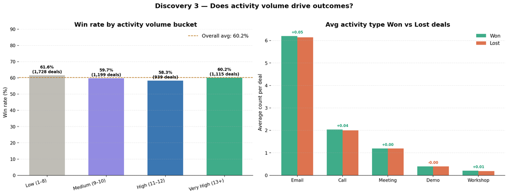

```
  Saved → /content/drive/MyDrive/Advanced Data Analytics/Enterprise Sales/sales_pipeline_outputs/D3_heatmap_stage_x_activity.png
```

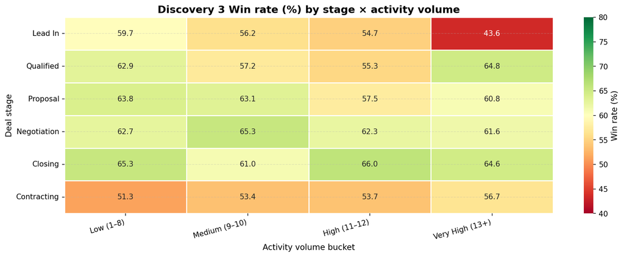

```
════════════════════════════════════════════════════════════
DISCOVERY 3 KEY FINDINGS
════════════════════════════════════════════════════════════

  Best performing bucket : Low (1–8) — 61.6% win rate
  Worst performing bucket: High (11–12) — 58.3% win rate

  Activity type differences (Won vs Lost):
    Email     : won deals have 0.05 more on avg  (+0.9%)
    Call      : won deals have 0.04 more on avg  (+1.9%)
    Meeting   : won deals have 0.00 more on avg  (+0.2%)
    Demo      : won deals have 0.00 fewer on avg  (-0.3%)
    Workshop  : won deals have 0.01 more on avg  (+5.6%)

  → High activity is not a clear predictor.
    The heatmap controls for stage — check whether the pattern
    holds within individual stages or only in aggregate.
════════════════════════════════════════════════════════════
```

The data demonstrates that there exists no significant positive connection between activity volume and win rate. The data shows that Low activity deals with 1 to 8 touches achieve their highest closing rate of 61.6 percent while High activity deals fail to reach this performance level. The stage × activity heatmap reveals why very high activity at Lead In correlates with a 43.6 percent win rate because deal stagnation causes excessive activity counts to increase. The only stage in contracting shows that increased activity leads to better results. The touch patterns of Won and Lost deals across all activity types match each other with only a 0.1 difference per deal.

**Recommendation**: Stop measuring rep effort by activity volume, it is not a proxy for performance and may actively mislead coaching decisions. Instead, track activity relative to stage progression: high activity with no stage movement is an early warning signal that a deal should be qualified out. Introduce a deal review trigger when activity exceeds 12 touches without a stage change.

## **Segment profitability by industry, company size & region**

This section identifies which customer segments generate the highest deal value and the best win rates, revealing where the sales team should focus acquisition effort and where they may be over-investing for poor returns.

```
Industry breakdown:
           Industry  total_deals  win_rate  avg_deal_size  total_won_val
         Healthcare          761 62.417871   52048.833114       23587396
      Manufacturing          642 61.526480   43128.901869       16645893
 Financial Services          669 61.285501  162827.128550       62108039
          Education          729 61.042524   54974.614540       24380530
Retail & E-commerce          780 58.846154   52231.173077       23469855
          Logistics          681 58.296623   50403.687225       19174403
         Technology          719 58.136300  174263.045897       71449316

Company size breakdown:
CompanySize  total_deals  win_rate  avg_deal_size  total_won_val
 Mid-Market         3506 60.838562   63207.173417      131187730
 Enterprise         1042 60.076775  169492.833973      100122700
        SMB          433 55.427252   42610.237875        9505002

Region breakdown:
company_region  total_deals  win_rate  avg_deal_size  total_won_val
  Asia-Pacific          752 62.765957   88593.448138       37393567
 Latin America          483 60.455487   89020.739130       26351470
        Europe         2870 59.790941   81019.565505      135952102
 North America          876 59.246575   85069.261416       41118293
  Saved → /content/drive/MyDrive/Advanced Data Analytics/Enterprise Sales/sales_pipeline_outputs/D4_segment_industry_and_size.png
```

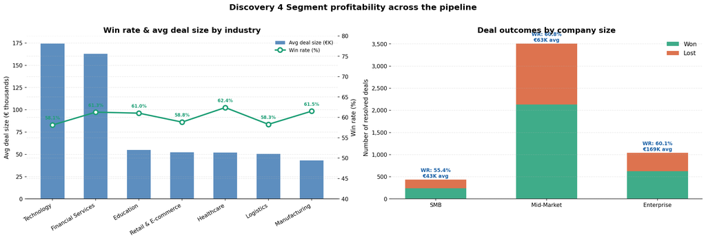

```
  Saved → /content/drive/MyDrive/Advanced Data Analytics/Enterprise Sales/sales_pipeline_outputs/D4_2x2_industry_bubble.png
```

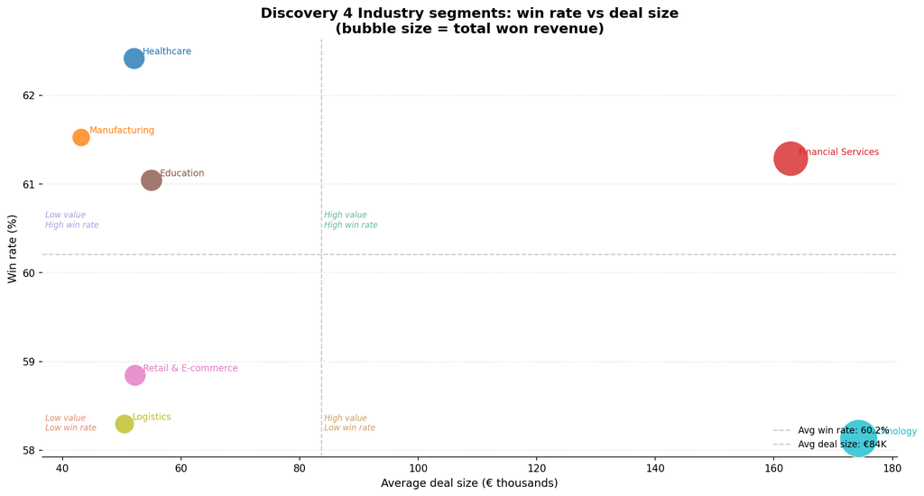

```
  Saved → /content/drive/MyDrive/Advanced Data Analytics/Enterprise Sales/sales_pipeline_outputs/D4_region_performance.png
```

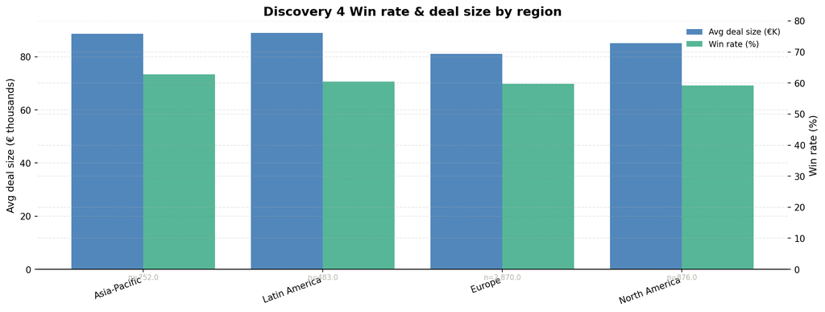

```
════════════════════════════════════════════════════════════
DISCOVERY 4 KEY FINDINGS
════════════════════════════════════════════════════════════

  Industry — highest win rate : Healthcare (62.4%)
  Industry — largest avg deal : Technology (€174,263)
  Industry — lowest win rate  : Technology (58.1%)

  Company size performance:
    SMB         : 55.4% WR  |  €42,610 avg deal  |  433 deals
    Mid-Market  : 60.8% WR  |  €63,207 avg deal  |  3,506 deals
    Enterprise  : 60.1% WR  |  €169,493 avg deal  |  1,042 deals

  Region — strongest : Asia-Pacific (62.8% WR)
  Region — weakest   : North America (59.2% WR)

  → Focus acquisition on segments in the top-right quadrant
    of the bubble chart: high win rate + high deal value.
════════════════════════════════════════════════════════════
```

What the data shows: Financial Services is the highest-value, high-win-rate segment, the clearest ideal customer profile in the dataset. Technology presents the opposite paradox: the largest average deals (€174K) paired with the lowest win rate (58.1%), suggesting significant effort is being spent on deals the team is statistically less likely to win. SMB is the only size segment below 60% win rate and generates the lowest average deal value, raising questions about resource allocation. Regionally, Asia-Pacific leads at 62.8% with a negligible spread across all four regions, indicating geography is not a meaningful performance differentiator.

**Recommendation**: Prioritise Financial Services pipeline development, it is the only industry combining high deal value with above-average close rates. Conduct a dedicated review of Technology deal loss reasons, particularly at Contracting stage, as the combination of high value and low win rate represents the largest recoverable revenue opportunity in the dataset. Re-evaluate SMB investment relative to the returns it generates versus Mid-Market.

## **Deal cycle time & year-over-year pipeline performance**

This section measures how long deals take to close across different segments and reps, then tracks whether the sales team is getting better or worse at converting pipeline value from 2022 through 2025.

```
Overall cycle time (days):
  Won deals  median: 100  mean: 138  max: 667
  Lost deals median: 91  mean: 127  max: 660

Cycle time by industry (median days):
           Industry  median_cycle  won_cycle  lost_cycle
 Financial Services         104.0      105.0       102.0
         Technology         104.0      105.0        98.0
         Healthcare         101.0      107.0        99.0
      Manufacturing          93.5      101.0        84.0
          Logistics          93.0       96.0        91.5
Retail & E-commerce          92.5       96.0        88.0
          Education          90.0       91.0        90.0

Cycle time by company size (median days):
CompanySize  median_cycle  won_cycle  lost_cycle
        SMB          86.0       86.0        84.0
 Mid-Market          97.0      101.0        90.0
 Enterprise         102.0      103.0        99.0

Year-over-year pipeline summary (2022–2025):
 created_year  total_deals   win_rate  avg_deal_size  total_revenue  median_cycle
         2022          414  67.874396   53653.731884       15325861          90.0
         2023         1674  65.232975   49966.185783       53698362          77.0
         2024            1 100.000000   69899.000000          69899          70.0
         2025         2892  56.189488  107448.193983      171721310         101.0
  Saved → /content/drive/MyDrive/Advanced Data Analytics/Enterprise Sales/sales_pipeline_outputs/D5_cycle_time_and_yoy.png
```

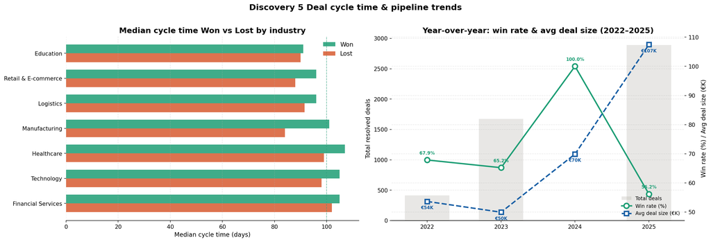

```
  Saved → /content/drive/MyDrive/Advanced Data Analytics/Enterprise Sales/sales_pipeline_outputs/D5_quarterly_win_rate_trend.png
```

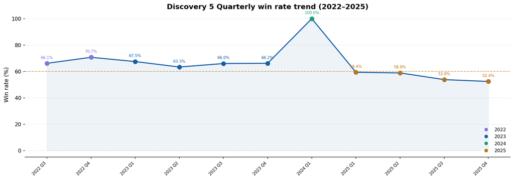

```
  Saved → /content/drive/MyDrive/Advanced Data Analytics/Enterprise Sales/sales_pipeline_outputs/D5_cycle_time_by_size_boxplot.png
```

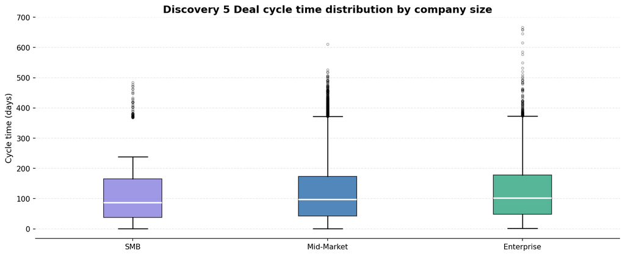

```
════════════════════════════════════════════════════════════
DISCOVERY 5 KEY FINDINGS
════════════════════════════════════════════════════════════

  Won deals  median cycle: 100 days  mean: 138 days
  Lost deals median cycle: 91 days  mean: 127 days

  Best year  : 2024 (100.0% win rate)
  Worst year : 2025 (56.2% win rate)
  WR trend (2022→2025)       : -11.7 percentage points
  Avg deal size trend        : €+53,794

  Cycle time by company size:
    SMB         : 86 days median  (Won: 86d  Lost: 84d)
    Mid-Market  : 97 days median  (Won: 101d  Lost: 90d)
    Enterprise  : 102 days median  (Won: 103d  Lost: 99d)

  → Win rate is declining over the 4-year period.
    Average deal size has grown by €53,794.
════════════════════════════════════════════════════════════
```

```
── 2024 data note ───────────────────────────────────────────────────────
  Total deals created in 2024 : 4
  Still Open                  : 3
  Resolved (Won/Lost)         : 1
  → 2024 is excluded from trend analysis due to insufficient resolved deals.
    Trend conclusions are drawn from 2022, 2023, and 2025 only.
```

**What the data shows:** The most significant trend in this dataset is a declining win rate alongside rapidly growing deal sizes, from 67.9% at €54K average in 2022, to 65.2% at €50K in 2023, to 56.2% at €107K in 2025 (2024 excluded due to a dataset gap with only 4 deals created). The team is successfully moving upmarket into larger deals but closing them at a materially lower rate, an 11.7 percentage point decline over three years. Lost deals resolve faster than won deals (91 vs 100 days median), reinforcing Discovery 3's finding that prolonged engagement does not improve outcomes. Enterprise deals show the widest cycle time variance, with outliers exceeding 600 days, making pipeline forecasting unreliable at that segment.

**Recommendation**: The upmarket shift is generating larger individual deals but eroding overall win rate, the sales motion, messaging, and rep capability need to be re-evaluated for the €100K+ deal profile that now dominates the pipeline. Introduce cycle time thresholds by company size: deals exceeding 200 days for SMB or 300 days for Enterprise should trigger automatic pipeline review. The quarterly trend shows 2025 consistently underperforming the historical average, this warrants an urgent diagnostic on what changed in go-to-market strategy between 2023 and 2025.

## **Executive Summary**

This section consolidates all five discoveries into a single, decision-ready summary, one headline finding and one concrete recommendation per discovery, written for a leadership audience that needs conclusions, not methodology.

```
═════════════════════════════════════════════════════════════════
  ENTERPRISE SALES PIPELINE EXECUTIVE FINDINGS SUMMARY
  Dataset: 2022–2025  |  11,750 deals  |  4,981 resolved  |  Overall win rate: 60.2%
  Total won revenue: €240.8M  |  Total lost pipeline: €175.9M
═════════════════════════════════════════════════════════════════

  DISCOVERY 1 WHERE DEALS DIE
  ─────────────────────────────────────────────────────────────────
  Finding : Lead In stage accounts for the most lost pipeline
            value at €51.2M. More critically, Contracting
            stage has the lowest win rate in the funnel at 54.7% a
            sharp drop from Closing at 64.4% meaning deals that
            have survived the entire sales cycle are still collapsing
            at the final hurdle. Total lost across all stages: €175.9M.

  Action  : Two interventions needed early qualification improvement
            at Lead In to reduce volume-driven losses, and a dedicated
            Contracting failure review (likely commercial, legal, or
            pricing issues surfacing too late in the process).

─────────────────────────────────────────────────────────────────

  DISCOVERY 2 REP PERFORMANCE VS SENIORITY
  ─────────────────────────────────────────────────────────────────
  Finding : Seniority tiers perform almost identically on win rate
            (Junior 59.3%, Mid 60.8%, Senior 60.1%), but Junior
            reps are closing deals €8.4K larger on average than
            Senior reps a structural inversion that warrants review.
            12 reps are performing meaningfully below their tier
            benchmark, with the most extreme gap at -25.9pp (Elena Dubois,
            Junior). 9 reps are punching above their tier, with
            Isabelle Pereira (Mid) closing at 73.1% win rate.

  Action  : Conduct individual reviews for the 12 below-tier reps.
            Examine whether Senior reps are being systematically assigned
            smaller accounts. Accelerate promotion conversations for
            consistently above-tier Junior and Mid performers.

─────────────────────────────────────────────────────────────────

```

[output cut: 42 more lines]

```
            Lost deals resolve faster than won deals (91 vs
            100 days median), confirming that prolonged cycles
            do not improve outcomes. Enterprise cycle time is highly
            variable with outliers exceeding 600 days.

  Action  : Re-evaluate sales motion, messaging, and rep capability
            for the €100K+ deal profile now dominating the pipeline.
            Set cycle time thresholds by segment flag deals exceeding
            200 days (SMB) or 300 days (Enterprise) for pipeline review.
            Conduct an urgent diagnostic on what changed between 2023
            and 2025 to drive the win rate decline.

═════════════════════════════════════════════════════════════════
  END OF EXECUTIVE SUMMARY
═════════════════════════════════════════════════════════════════
```

## **Export**

This section saves all charts as high-resolution PNGs ready for PowerPoint, and converts the full notebook into a clean, standalone HTML report that anyone on the team can open in a browser without needing Jupyter or Python.

```
── Checking saved chart files ───────────────────────────────────────────
  D1_win_rate_by_stage.png                      ✓  305 KB
  D1_lost_value_by_stage.png                    ✓  195 KB
  D2_rep_win_rate_by_seniority.png              ✓  279 KB
  D2_scatter_win_rate_vs_deal_size.png          ✓  366 KB
  D3_activity_vs_outcome.png                    ✓  301 KB
  D3_heatmap_stage_x_activity.png               ✓  252 KB
  D4_segment_industry_and_size.png              ✓  452 KB
  D4_2x2_industry_bubble.png                    ✓  250 KB
  D4_region_performance.png                     ✓  190 KB
  D5_cycle_time_and_yoy.png                     ✓  416 KB
  D5_quarterly_win_rate_trend.png               ✓  196 KB
  D5_cycle_time_by_size_boxplot.png             ✓  135 KB

  ✓ All charts present.

── Generating HTML executive summary ────────────────────────────────────
  ✓ HTML report saved → /content/drive/MyDrive/Advanced Data Analytics/Enterprise Sales/sales_pipeline_outputs/sales_pipeline_executive_report.html
    File size: 4461 KB (charts embedded inline)

── Exporting notebook to HTML ───────────────────────────────────────────
```

```
  ⚠ No .ipynb file found in /content save the notebook first.

═════════════════════════════════════════════════════════════════
✓ PHASE 5 COMPLETE, ALL OUTPUTS SAVED
═════════════════════════════════════════════════════════════════

  Output folder: /content/drive/MyDrive/Advanced Data Analytics/Enterprise Sales/sales_pipeline_outputs

  Charts (12 files):
    · D1_win_rate_by_stage.png
    · D1_lost_value_by_stage.png
    · D2_rep_win_rate_by_seniority.png
    · D2_scatter_win_rate_vs_deal_size.png
    · D3_activity_vs_outcome.png
    · D3_heatmap_stage_x_activity.png
    · D4_segment_industry_and_size.png
    · D4_2x2_industry_bubble.png
    · D4_region_performance.png
    · D5_cycle_time_and_yoy.png
    · D5_quarterly_win_rate_trend.png
    · D5_cycle_time_by_size_boxplot.png

  Reports:
    · sales_pipeline_executive_report.html  ← primary deliverable
    · sales_pipeline_analysis.html          ← full notebook export

  To share: download the HTML report from Google Drive.
  It opens in any browser, no Python or Jupyter needed.
═════════════════════════════════════════════════════════════════
```